# Reproducible Research: Peer Assessment 1

Bart Decaigny

Wednesday, October 15, 2014

## Loading and preprocessing the data

The goal of this assignment is to analyse data from personal movement activity, in this case, the number of steps taken by an anonymous individual over the course of two months, measured in five minute intervals.

## What is mean total number of steps taken per day?

But before there’s anything we can do, we need to load the data, remove NA values, clean up, aggregate… to be able to show an overview of the steps taken per day:

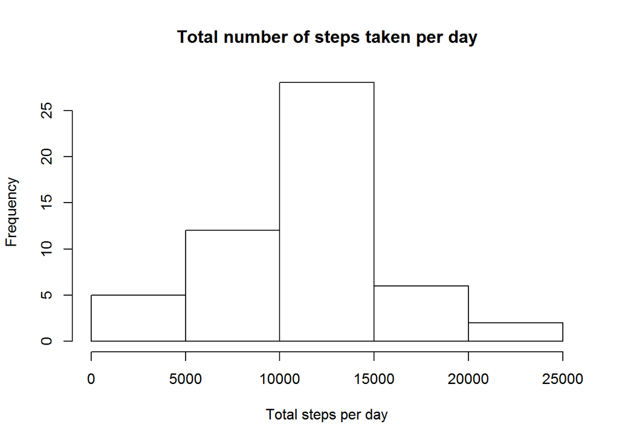

The mean and average of steps taken per day can also be calculated:

```
##    Min. 1st Qu.  Median    Mean 3rd Qu.    Max.
##      41    8840   10800   10800   13300   21200
```

## What is the average daily activity pattern?

Instead of summarizig per day, we could also calculate the average number of steps taken per 5-minutes interval, and plot it out:

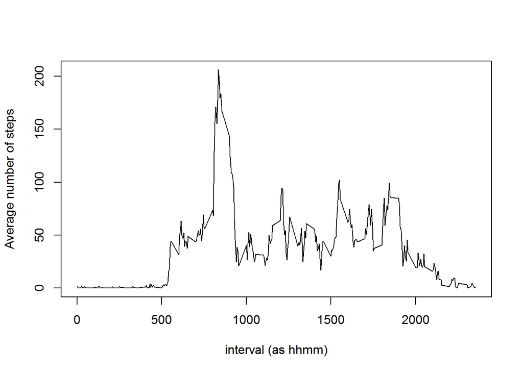

We can see that the max number of steps taken is 206, at 8:35 AM, when ordering the intervals by average steps (only top 5 shown):

```
##     interval avg_steps
## 104      835     206.2
## 105      840     195.9
## 107      850     183.4
## 106      845     179.6
## 103      830     177.3
```

## Imputing missing values

As mentioned earlier, these calculations use the cleaned up data set, i.e. with the NA rows removed. In the original table, there are 2304 NA rows on a total of 17568 rows. In stead of working with reduced data set as with did thusfar, we could also choose to replace the missing values with calculated data, e.g. the average number of steps for that time interval, or for that date. As we see quite a strong pattern in the average steps per interval, we prefer to replace the NA values with the interval means.

Let’s check what the impact is on the total number of steps per day resp. on the average steps per day.

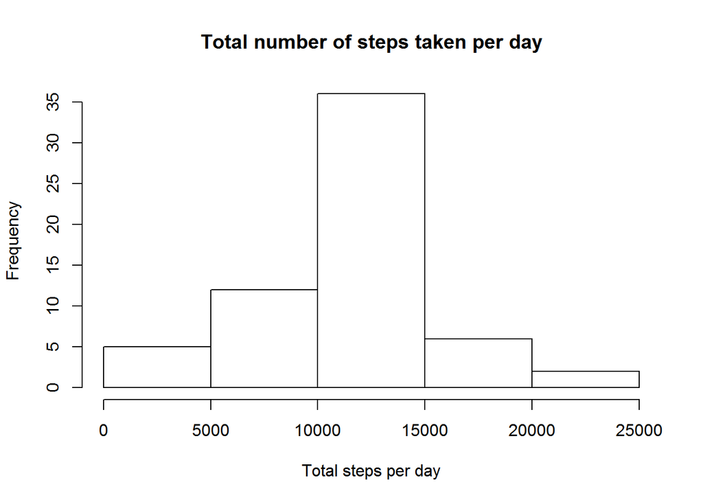

The mean and average of steps taken per day can also be recalculated:

```
##    Min. 1st Qu.  Median    Mean 3rd Qu.    Max.
##      41    9820   10800   10800   12800   21200
```

We can conclude that replacing the NAs with interval means has an impact on the quantile boundaries, but not on the mean or the median. When we recreate a plot for the average number of plots per interval, we see there is no impact either.

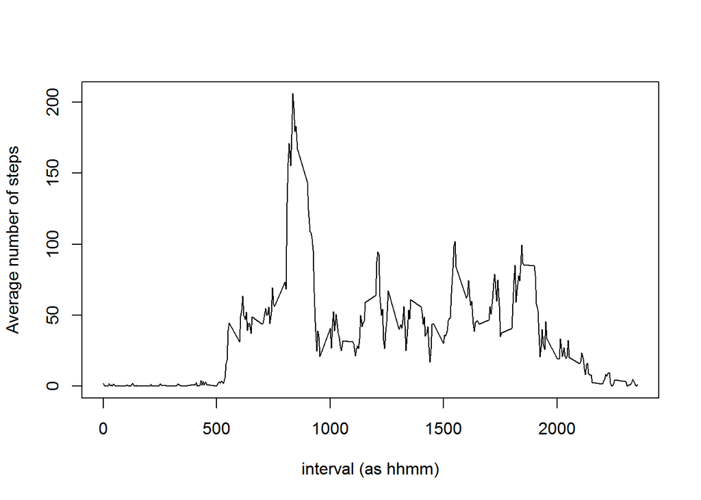

This was expected, of course, as we replaced the missing values with the averages already used in the plot.

## Are there differences in activity patterns between weekdays and weekends?

A last question we can ask ourselves, is wether there is a differences between steps taken on weekdays versus weekend. Let’s put this in a plot.

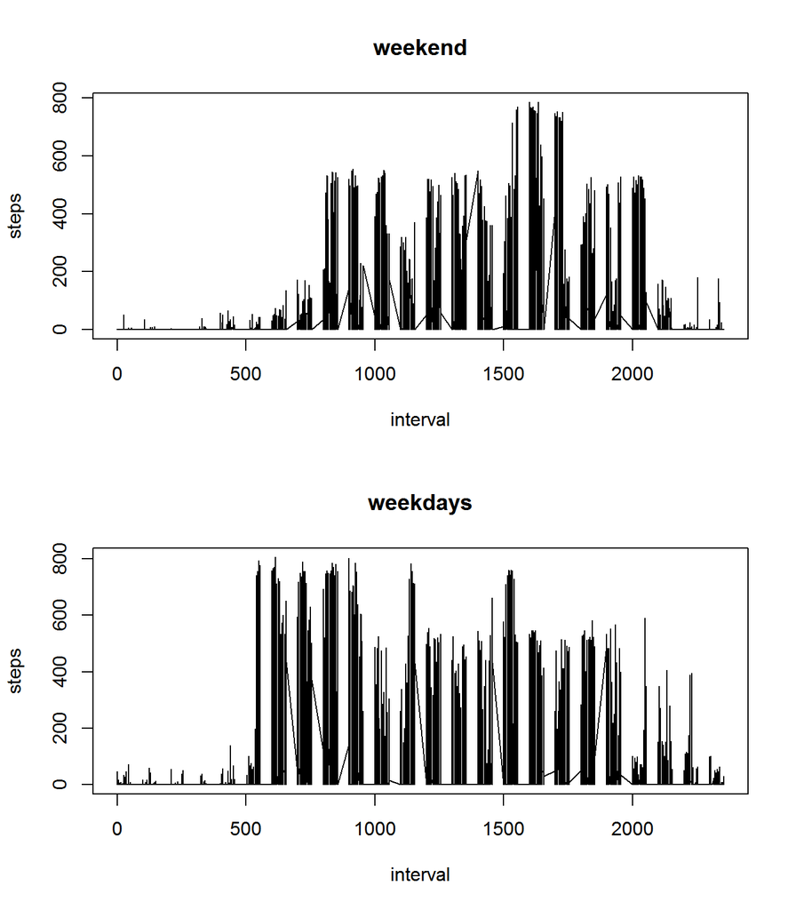

As could be expected, the activity kicks in quite a few hours later in the weekend, and pekas in the late afternoon, instead of in the morning.